To plot the model with interaction I could conveniently use `geom_smooth`

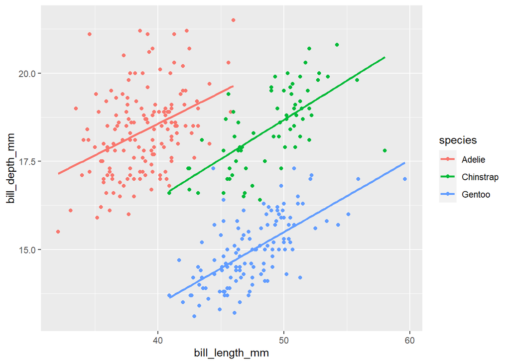

```r
g2 +
  geom_smooth(method = "lm", se = FALSE)
```

To plot th model without interaction, you can either extract the model coefficients or use the predict function.

Extracting the model coefficients starts to become complicated, as we have 3 intercepts and 1 slope to extract:

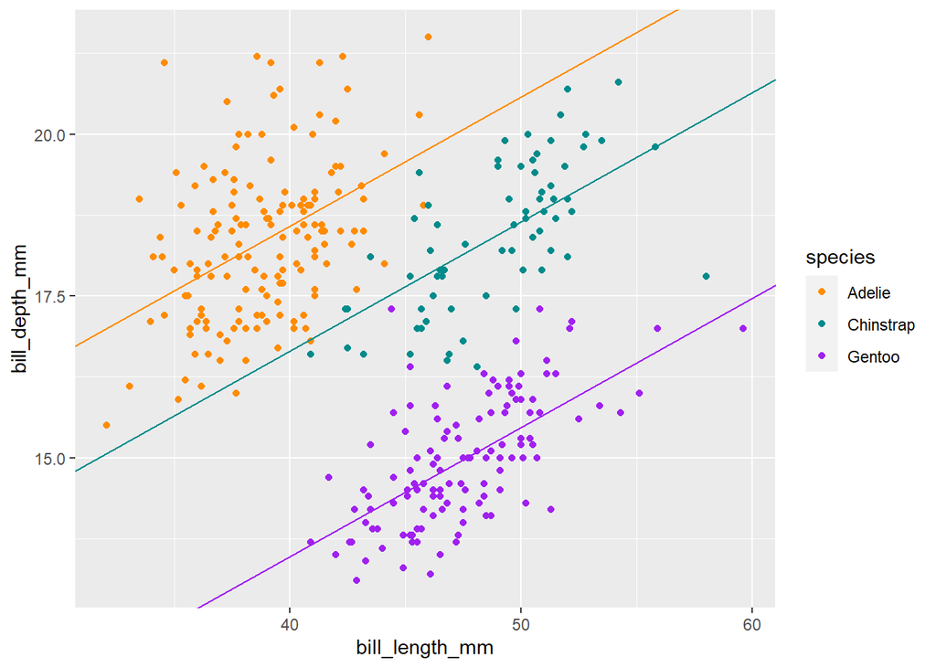

```r
# Option 1: extract model coefficients
intercept_adelie <- lm2a$coefficients[1]
slope <- lm2a$coefficients[2]
intercept_chinstrap <- intercept_adelie + lm2a$coefficients[3]
intercept_gentoo <- intercept_adelie + lm2a$coefficients[4]

# lets add some custom colors
cols <- c("darkorange", "cyan4", "purple")

g2 +
  geom_abline(slope = slope, intercept = intercept_adelie, color = cols[1]) +
  geom_abline(slope = slope, intercept = intercept_chinstrap, color = cols[2]) +
  geom_abline(slope = slope, intercept = intercept_gentoo, color = cols[3]) +
  scale_color_manual(values = cols)
```

It is easier to use the `predict` function in this case:

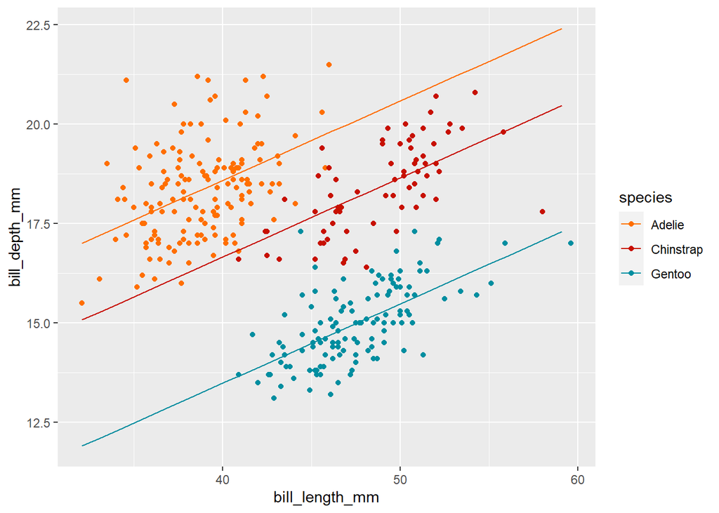

```r
pred_dat <- expand_grid(
  bill_length_mm = min(penguins$bill_length_mm, na.rm = TRUE):max(penguins$bill_length_mm, na.rm = TRUE),
  species = c("Adelie", "Chinstrap", "Gentoo")
)
pred_dat$bill_depth_mm <- predict(lm2a, newdata = pred_dat)

g2 +
  geom_line(data = pred_dat) +
  ggsci::scale_color_futurama()
```

### 1.4 Anova

Do male and female penguins differ in weight and does this depend on the species?

First, we create a subset without penguins for which the sex is unknown

```r
penguins_sex <- filter(penguins, !is.na(sex))
```

The question can be represented for example with a boxplot

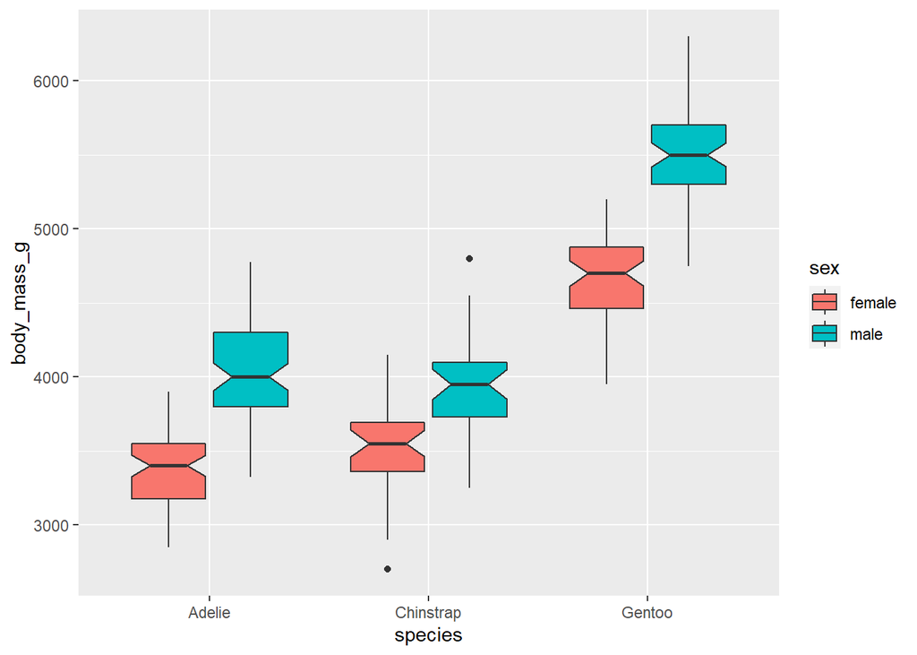

```r
ggplot(penguins_sex, aes(x = species, y = body_mass_g, fill = sex)) +
  geom_boxplot(notch = TRUE)
```

- Fit a linear model that represents this question

```r
# Without interaction
lm3a <- lm(body_mass_g ~ sex + species, data = penguins_sex)
# Without interaction
lm3b <- lm(body_mass_g ~ sex + species + sex:species, data = penguins_sex)
```

- Test for significant predictors

Both the single effect and the interaction is significant.

```r
drop1(lm3a, test = "F")
```

```
## Single term deletions
##
## Model:
## body_mass_g ~ sex + species
##         Df Sum of Sq       RSS    AIC F value    Pr(>F)
## <none>                32979185 3838.6
## sex      1  37090262  70069447 4087.5  370.01 < 2.2e-16 ***
## species  2 143401584 176380769 4392.9  715.29 < 2.2e-16 ***
## ---
## Signif. codes:  0 '***' 0.001 '**' 0.01 '*' 0.05 '.' 0.1 ' ' 1
```

```r
drop1(lm3b, test = "F")
```

```
## Single term deletions
##
## Model:
## body_mass_g ~ sex + species + sex:species
##             Df Sum of Sq      RSS    AIC F value    Pr(>F)
## <none>                   31302628 3825.2
## sex:species  2   1676557 32979185 3838.6   8.757 0.0001973 ***
## ---
## Signif. codes:  0 '***' 0.001 '**' 0.01 '*' 0.05 '.' 0.1 ' ' 1
```

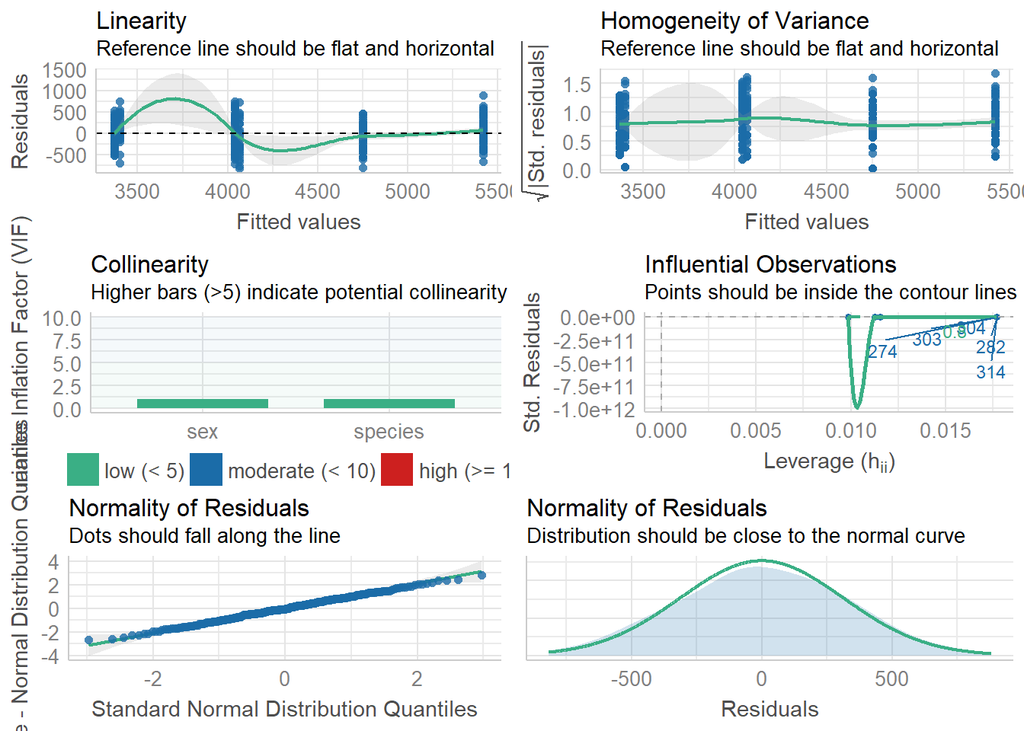

```r
check_model(lm3a)
```

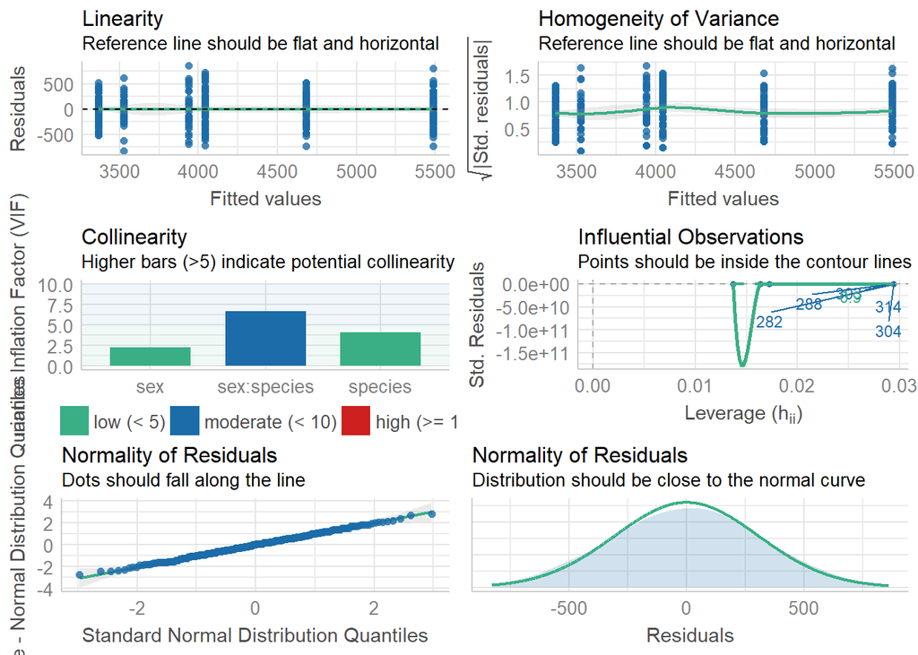

```r
check_model(lm3b)
```

#### Extra

Some other plots with which we can represent the results of the Anova.

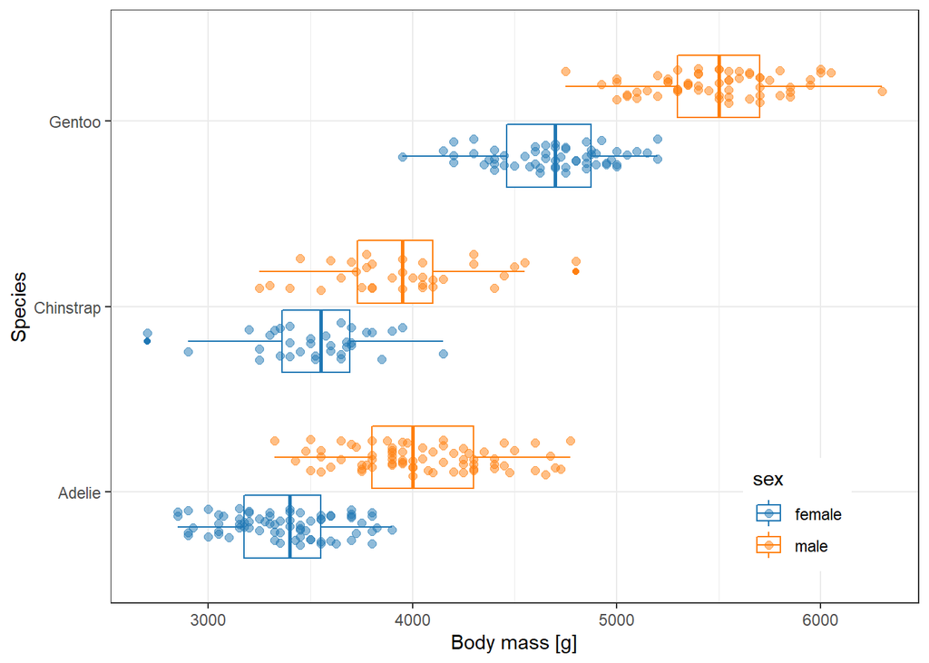

```r
penguins_sex %>%
  ggplot(aes(
    x = species,
    y = body_mass_g,
    color = sex
  )) +
  geom_boxplot() +
  geom_point(
    size = 2, alpha = 0.5,
    position = position_jitterdodge(
      seed = 123
    )
  ) +
  coord_flip() +
  ggsci::scale_color_d3() +
  labs(y = "Body mass [g]", x = "Species") +
  theme_bw() +
  theme(legend.position = c(0.85, 0.15))
```

```r
summary <- penguins_sex %>%
  group_by(species, sex) %>%
  summarize(
    sd = sd(body_mass_g),
    mean = mean(body_mass_g)
  )
```

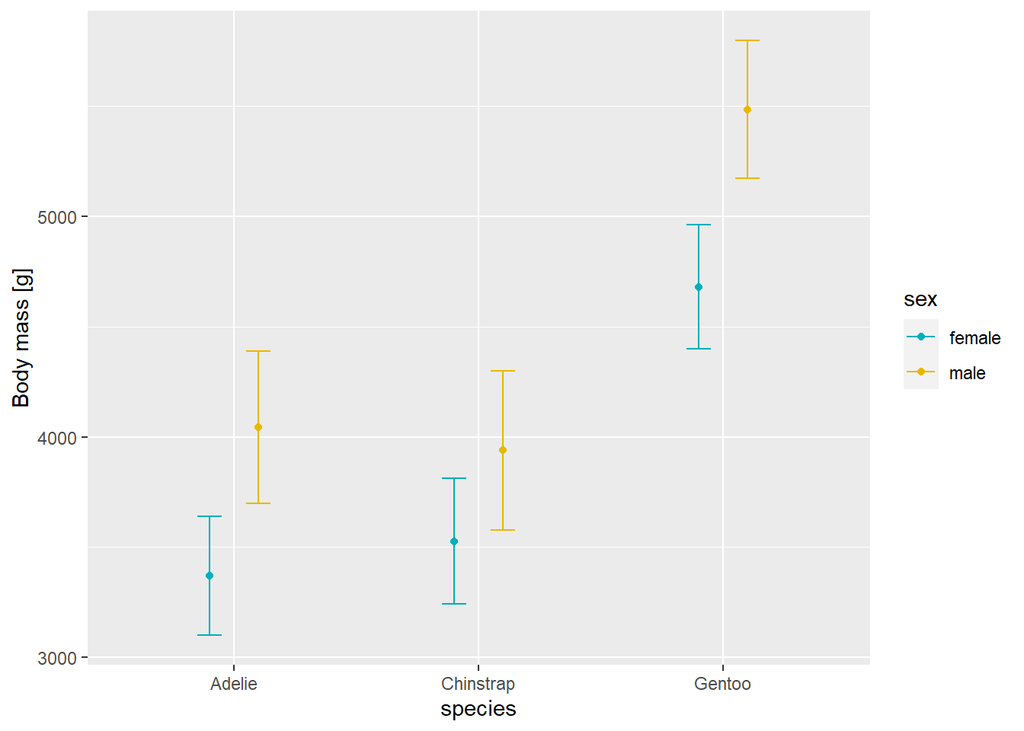

```r
ggplot(summary, aes(x = species, y = mean, color = sex)) +
  geom_point(position = position_dodge(0.4)) +
  geom_errorbar(
    aes(ymin = mean - sd, ymax = mean + sd),
    position = position_dodge(0.4),
    width = 0.2
  ) +
  scale_color_manual(values = c("#00AFBB", "#E7B800")) +
  labs(y = "Body mass [g]")
```

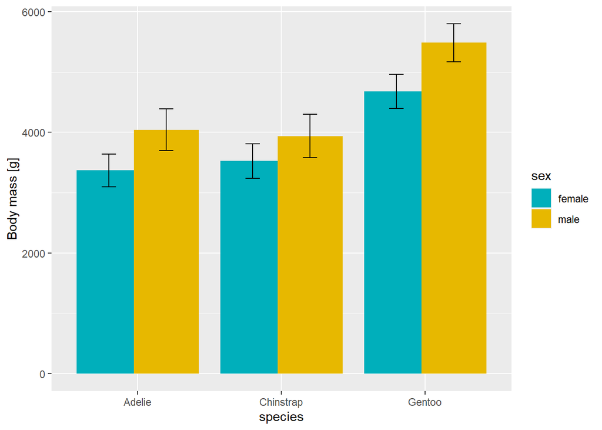

```r
ggplot(summary, aes(x = species, y = mean, fill = sex)) +
  geom_col(position = position_dodge(0.8)) +
  geom_errorbar(
    aes(ymin = mean - sd, ymax = mean + sd),
    position = position_dodge(0.8),
    width = 0.2
  ) +
  scale_fill_manual(values = c("#00AFBB", "#E7B800")) +
  labs(y = "Body mass [g]")
```